#### **To: Manager, Seattle Reign Project**

#### **From: Ankita Pathak**

#### **Seattle Reign FC sales consulting for generating additional interest in the community**

# Introduction

On performing an exploratory data analysis of Sales, Attendance, Media Consumption and Merchandise Consumption, a case study of a Soccer Team Seattle Reign FC, I would recommend changes in the promotional strategy for increasing merchandise consumption and a predictive approach to focus on target audience during the upcoming Season 2017. A survey was conducted with four sections which contains a combination of past attendance behaviors, behavior intentions, psychographics, and demographics. The survey was distributed online through the mailing list provided by the Seattle Reign FC organization. I obtained 684 useable survey responses and will be using it to find ways to increase ticket sales and attendance. I believe that sales of many of the Seattle Reign FC merchandise and tickets could increase if we analyze the current market trends, do necessary promotions and provide sufficient target products.

# Recommendations

As apparent from the figure below, I would suggest the following recommendations. I believe that they will help Seattle Reign FC to find out the effectiveness of promotions to increase Merchandise consumption and Attendance likelihood for Season 2017:

### 1. My primary recomendation is to check the merchandise buying preferences and average expenditure over the 2016 season for people who have attended 2016 season.

- The expenditure graph below shows that the Merchandises are more likely to sell Online or during the Match.
- Short Sleeve Shirts are most popular among all the different types of Merchandises. Least popular Merchandise categories are Accessories and Jackets

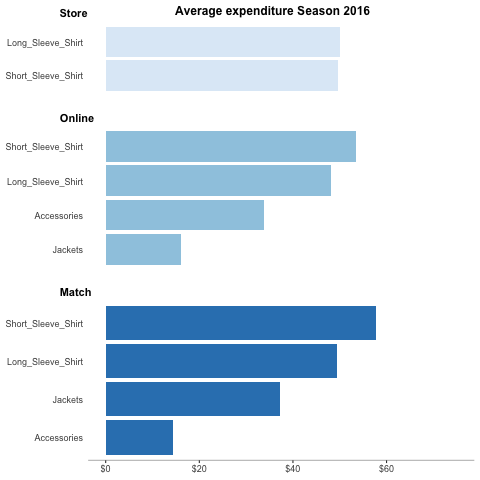

#### a. Promotional Strategy

- As evident from the below graph, Short Sleeve Shirts and Accessories sell most when promotions have positive influence
- Long Sleeve Shirts and Jackets are selling even if there is no influence of promotions which means it is important to focus on promotional strategy for products like Short Sleeve Shirts and Accessories
- I would suggest not only to develop a viable strategy to increase promotions but also do a deeper market research to see if there is adequate demand to increase the sale of any merchandise during the match
- An approach for selling more Short Sleeve Shirts would be providing offers like buy 1 get 1 free, a pack of 2 Short Sleeve Shirts for lesser price

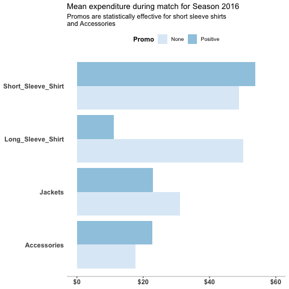

#### b. Impact of Sponsors

- Pepsi is among the most popular sponsors of all Merchandises during the Season 2016 except Long Sleeve Shirts
- Seattle Reign FC can focus on sales of Short Sleeve Shirts during the match because it is most selling merchandise for all sponsors
- Target on what a fan likes the most on Merchandise, for example, a logo of Seattle Reign FC on front or the logo of Sponsors

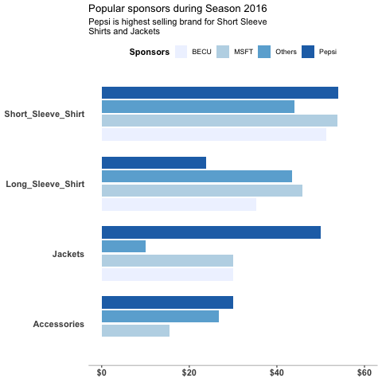

### 2. My second recommendation would be to identify which type of ticket sells the most and at what timings of the day fans like to attend the match for the upcoming season 2017?

- The figure below indicates that Season ticket is predicted to sell highest for the upcoming Season 2017, 5 Match Pack is least likely to sell
- Sunday Evenings is the most popular timing among fans to attend the Seattle Reign FC match
- Target more promotions on all the preferred timings for the Season Ticket, for example, Sunday Afternoons 4pm and Saturday Afternoons 4pm

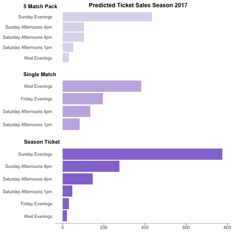

#### a. Promotional Strategy

- In comparison to other preferred timings, Saturday Afternoon 1pm and Sunday Evenings tickets are likely to sell more when promotions are effective
- A strategy to sell more tickets on these preferred timings would be to provide offers on Season Tickets purchase, for example, free food coupon with ticket
- It would be beneficial to have more detailed analysis, like finding out promotional strategies by looking at market trends to find out consumer’s demand. For example, before providing promotions like 15% off on Memberships for Season Tickets, it is essential to find out whether customer is willing to spend on memberships?

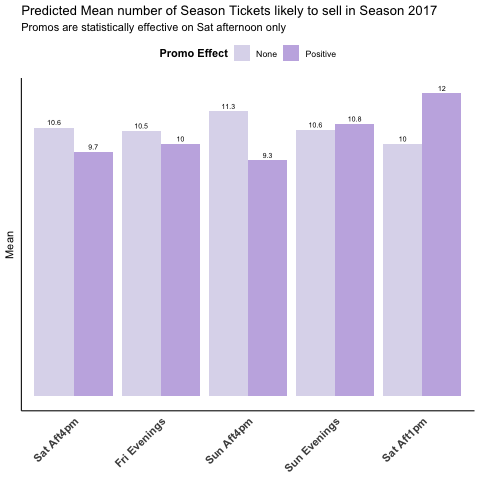

#### b. Target audience

- Since, only College Graduates are likely to attend matches on Saturday Afternoons 1pm, it is important to find out reasons of why the College and Graduate students are not attending the match, is the distance of stadium far from the city to attend with family?
- Seasonal Tickets can use certain characters or mascots for as a “free gift with purchase” to better connect with customers as they help in building a relationship between brand and consumers
- Another observation of the data reveals that customers are more likely to attend evening/4pm matches during the weekend, hence, to accomodate more number of audiences advertise that additional parking facility will be available for all visitors

[figure not shown]

## Conclusion

Please do not hesitate to contact me if you have questions or would like to discuss the analysis further. I can also provide my complete analysis with data and code if you would like more detail.

Best regards,

Ankita Pathak